# Lab 3: Lexicon-Based Sentiment Analysis with Bluesky Data

2026-04-27

## Overview

In this lab we’ll collect posts from Bluesky Social using the `{atrrr}` package and apply lexicon-based sentiment analysis tools — the same tools we covered in lecture (VADER via `{vader}`, `{sentimentr}`, and `{tidytext}` lexicons). By the end you’ll have a working pipeline from API call to sentiment scores, and you’ll have a concrete sense of where these tools succeed and where they fall short. We’ll walk through some of this in class with sample data, then you’ll be responsible for completing it with your own data set for the assignment.

## Setup

### 1. Create a Bluesky account and app password (you’ll do this your assignment)

### 2.Packages

```r
#install.packages(c("atrrr", "tidyverse", "tidytext", "sentimentr", "remotes", "devtools"))

# tidyvader isn't on CRAN:
#remotes::install_github("chris31415926535/tidyvader")
```

```r
library(atrrr)
library(tidyverse)
library(tidytext)
library(sentimentr)
library(remotes)
library(tidyvader)
```

## Part 1: Authenticate and Pull Posts

Now search for posts on an environmental keyword. We’ll use `"climate change"` as the default — feel free to swap in another term relevant to your interests.

```r
# raw_posts <- search_post("climate change", limit = 1000) #you'll do this later

raw_posts <- read.csv("https://raw.githubusercontent.com/MaRo406/EDS-231-text-sentiment/refs/heads/main/data/bluesky_climate_raw.csv")
```

Take a look at what came back:

```r
glimpse(raw_posts)
```

[output not shown]

The key columns for our purposes are `text` (post content) and `uri` (unique identifier), and engagement metrics like `like_count` and `reply_count`.

## Part 2: Clean and Prepare Text

Pull out the columns we need and do basic cleaning.

```r
posts <- raw_posts |>
  select(uri, indexed_at, text, like_count, reply_count, repost_count) |>
  mutate(
    indexed_at = as.POSIXct(indexed_at), #who can tell me how to
    post_date  = as.Date(indexed_at),
    text_clean = str_remove_all(text, "https?\\S+"), #remove URLs
    text_clean = str_remove_all(text_clean, "@\\S+"),#remove mentions
    text_clean = str_replace_all(text_clean,"\u2019", "'"),
    text_clean = str_remove_all(text_clean, "'s\\b"),
    text_clean = str_squish(text_clean)

  ) |>
  filter(nchar(text_clean) > 10)
```

How many posts do we have?

```r
nrow(posts)
```

```
## [1] 1072
```

## Part 3: Word Frequency

Before running any sentiment analysis, look at what words are actually in the data and plot the most frequent.

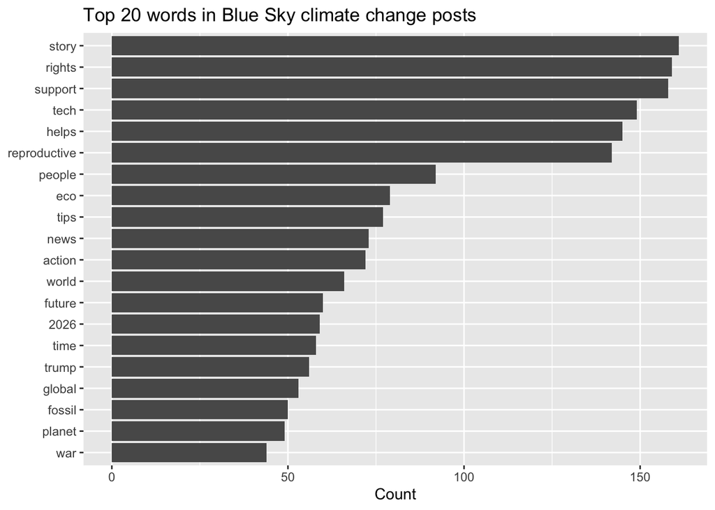

```r
# pass 1: standard stop words
data("stop_words")

tokens_clean <- posts |>
  unnest_tokens(word, text_clean) |>
  anti_join(stop_words, by = "word")

# pass 2: custom stop words and additional cleaning
custom_sw <- tibble(word = c(
  # search terms
  "climate", "change"
  # other common but uninformative text?
))

tokens_clean2 <- tokens_clean |>
  anti_join(custom_sw, by = "word")

# word frequency plot

word_counts <-tokens_clean2 |>
  count(word, sort =TRUE)

word_counts |>
  slice_max(n, n=20) |>
  ggplot(aes(x=reorder(word, n), y=n)) +
           geom_col() +
           coord_flip() +
            labs(title = "Top 20 words in Blue Sky climate change posts",
                 x =NULL, y = "Count") +
  coord_flip()
```

## Part 4: Sentiment Analysis

> **Note:** If you need to re-run any chunk in this section, run `rm(posts)` in the console first and re-run from Part 2. This avoids duplicate column errors.

### 4a. Bing lexicon (word-level)

Use `get_sentiments("bing")` to load the lexicon, then tokenize with `unnest_tokens()`, join to the lexicon with `inner_join()`, and compute a net score (positive word count minus negative word count) per post. Join the scores back onto `posts` with `left_join()`.

```r
bing <- get_sentiments("bing")

#score posts with Bing
bing_scores <- posts |>
  unnest_tokens(word, text_clean) |>
  inner_join(bing, by = "word") |>
  count(uri, sentiment) |>
  pivot_wider(names_from = sentiment, values_from = n, values_fill = 0) |>
  mutate( bing_score = positive - negative)

#join scores to posts
posts <- posts |>
  left_join(bing_scores, by = "uri") |>
  mutate(bing_score = replace_na(bing_score, 0 ))
```

### 4b. AFINN lexicon (numeric scores)

Load with `get_sentiments("afinn")`. Unlike Bing, each matched word carries an integer value (−5 to +5), so summarize by summing those values within each post using `group_by()` and `summarise()`.

```r
# You will be prompted to download the AFINN lexicon the first time —
# run this line in the console and select Yes, then it will be cached locally
afinn <- get_sentiments("afinn")

#score text
afinn_scores <- posts |>
  unnest_tokens(word, text_clean) |>
  inner_join(afinn, by = "word") |>
  group_by(uri) |>
  summarise(afinn_score = sum(value), .groups = "drop")

#join scores to posts
posts <- posts |>
  left_join(afinn_scores, by = "uri") |>
  mutate(afinn_score = replace_na(afinn_score, 0))
```

### 4c. NRC lexicon (emotion categories)

The NRC lexicon tags words with 8 emotions (anger, fear, anticipation, trust, surprise, sadness, joy, disgust) plus positive/negative. Now count emotion words per post and visualize which emotions dominate the corpus.

```r
nrc <- get_sentiments("nrc")

#plot
nrc_scores <- posts |>
  unnest_tokens(word, text_clean) |>
  inner_join(nrc, by = "word", relationship = "many-to-many") |>
  filter(!sentiment %in% c("positive", "negative")) |>
  count(uri, sentiment, name = "n")

#join scores to post
posts <- posts |>
  left_join(
    nrc_scores |>
      group_by(uri) |>
      summarise(nrc_emotion_words = sum(n), .groups = "drop"),
    by = "uri"
  ) |>
  mutate(nrc_emotion_words = replace_na(nrc_emotion_words, 0))
```

Which emotions dominate the corpus? Plot the count of total scored words for each of the 8 emotions.

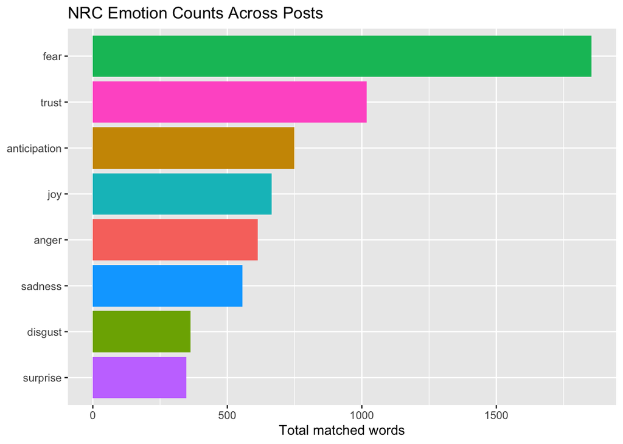

```r
nrc_scores |>
  group_by(sentiment) |>
  summarise(total_words = sum(n), .groups = "drop") |>
  ggplot(aes(x = reorder(sentiment, total_words), y = total_words, fill = sentiment)) +
  geom_col(show.legend = FALSE) +
  coord_flip() +
  labs(
    title = "NRC Emotion Counts Across Posts",
    x = NULL,
    y = "Total matched words"
  )
```

What words are driving each emotion? Create plots of the top 10 words for each emotion (hint: ggplot and `facet_wrap(~sentiment)`).

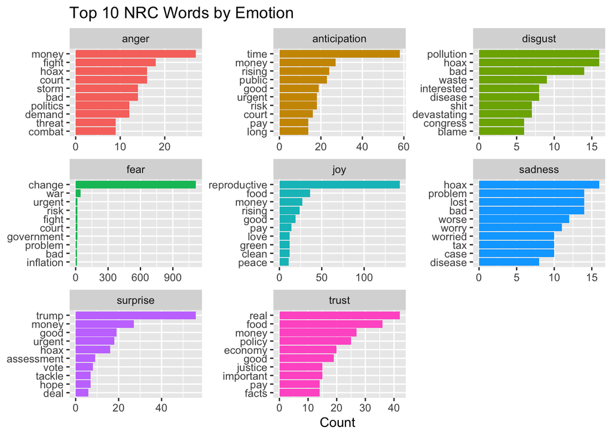

```r
posts |>
  unnest_tokens(word, text_clean) |>
  inner_join(nrc, by = "word", relationship = "many-to-many") |>
  filter(!sentiment %in% c("positive", "negative")) |>
  count(sentiment, word, sort = TRUE) |>
  group_by(sentiment) |>
  slice_max(order_by = n, n = 10, with_ties = FALSE) |>
  ungroup() |>
  ggplot(aes(x = tidytext::reorder_within(word, n, sentiment), y = n, fill = sentiment)) +
  geom_col(show.legend = FALSE) +
  facet_wrap(~sentiment, scales = "free") +
  coord_flip() +
  tidytext::scale_x_reordered() +
  labs(
    title = "Top 10 NRC Words by Emotion",
    x = NULL,
    y = "Count"
  )
```

### 4d. sentimentr (sentence-aware)

Unlike the word-level lexicons above, `{sentimentr}` scores at the sentence level and handles valence shifters like negation — “not alarming” won’t score the same as “alarming.” Pass the full `text_clean` vector to `sentiment_by()`. Rename the resulting `ave_sentiment` to `sr_scores` and join back onto `posts` by row index. I’ll give you this code as we haven’t fully covered this yet.

```r
sr_scores <- sentiment_by(posts$text_clean) |>
  select(element_id, ave_sentiment) |>
  rename(sr_score = ave_sentiment) |>
  mutate(element_id = as.integer(element_id))

posts <- posts |>
  mutate(element_id = row_number()) |>
  left_join(sr_scores, by = "element_id")
```

### 4e. VADER

VADER scores the full post text (no tokenization needed) and returns four values: `pos`, `neu`, `neg`, and `compound`. Use `tidyvader::vader()` on the `text_clean` column — it mutates the result directly onto the dataframe. Keep only the `compound` score and drop the component columns.

Let’s run VADER on a single post manually before applying it to the whole dataset:

```r
# look at a few posts
posts |> select(text_clean) |> slice(1:10)

# run VADER on one post — swap in whichever row looks interesting to you
posts$text_clean[3]
tidyvader::vader_chr(posts$text_clean[3])
```

[output not shown]

What did VADER catch? What did it miss? How does the compound score relate to the word-level scores?

## Now score all the posts with VADER. Rename it’s default scoring column to `vader_score`.

```r
posts <- posts |>
  mutate(vader_score = purrr::map_dbl(text_clean, ~ tidyvader::vader_chr(.x)$compound))
```

## Part 5: Compare the Methods

### Correlations

Let’s see to what extent the 4 numerical methods (bing, afinn, sr, and vader) are in agreement. Select the 4 scores and use `cor()` using “complete.obs”.

```r
posts |>
  select(bing_score, afinn_score, sr_score, vader_score) |>
  cor(use = "complete.obs")
```

```
##             bing_score afinn_score  sr_score vader_score
## bing_score   1.0000000   0.7103011 0.5870491   0.6316745
## afinn_score  0.7103011   1.0000000 0.6447093   0.8004395
## sr_score     0.5870491   0.6447093 1.0000000   0.6213586
## vader_score  0.6316745   0.8004395 0.6213586   1.0000000
```

### Score distributions

Use `pivot_longer()` to reshape the four score columns into a single `score` column with a `method` identifier, then plot with `geom_histogram()` and `facet_wrap()`.

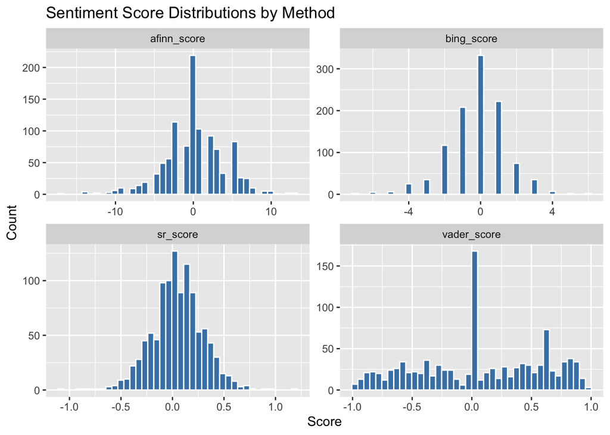

```r
posts |>
  select(bing_score, afinn_score, sr_score, vader_score) |>
  pivot_longer(
    cols = everything(),
    names_to = "method",
    values_to = "score"
  ) |>
  ggplot(aes(x = score)) +
  geom_histogram(bins = 40, fill = "steelblue", color = "white") +
  facet_wrap(~method, scales = "free") +
  labs(
    title = "Sentiment Score Distributions by Method",
    x = "Score",
    y = "Count"
  )
```

**Question 1:** Do the four methods broadly agree or disagree? Where do you see the biggest differences in the distributions? Which method produces the most zeros, and why?

Broadly, the methods do agree as all the distributions are centered around 0 meaning most of the posts are neutral. AFINN and Bing are discrete so we see a big difference in the number of zeros and bin sizes, with Bing having the most zeros (nearly 350) because it only counts positive/negative words and many posts may have none of those so are 0. Another big difference is the bimodality of Vader scores which stretch to +1 and -1 while the others show roughly a normal distribution. All of them seem to have slightly more values on the positive side but it is close.

## Part 6: Spot-Check for Misclassification

Find posts where the methods disagree most — these are the best candidates for understanding failure modes. Use `mutate()` to create binary flags from the continuous scores, then `filter()` for posts where the two methods point in opposite directions.

```r
posts |>
  mutate(
    bing_flag = sign(bing_score),
    vader_flag = sign(vader_score)
  ) |>
  filter(
    bing_flag != 0,
    vader_flag != 0,
    bing_flag != vader_flag
  ) |>
  select(uri, text_clean, bing_score, vader_score, afinn_score, sr_score) |>
  arrange(desc(abs(bing_score - vader_score)))
```

To rank posts by total disagreement, compute the absolute difference between the two scores with `abs()`, then `arrange(desc(...))` to surface the highest-conflict posts.

```r
posts |>
  mutate(
    bing_z = as.numeric(scale(bing_score)),
    vader_z = as.numeric(scale(vader_score)),
    conflict = abs(bing_z - vader_z)
  ) |>
  arrange(desc(conflict)) |>
  select(uri, text_clean, bing_score, vader_score, afinn_score, sr_score, conflict) |>
  slice_head(n = 10)
```

[output not shown]

**Question 2:** Read through 5 of the high-conflict posts. For each one, write a sentence explaining which method you think is closer to correct and why.

1. The first post is very ironic and sarcastic. Bing would score many words as positive when really the tone is cynical which might be better scored by VADER.
2. SR here is best because this post uses negative keywords in a positive framework but SR uses the whole sentence structure so it would correctly identify it as a call to action instead of a negative rant.
3. For this sciency announcement post AFINN would be best because it doesn’t over-interpret words like “adaptation” or “persistence” as emotional but still captures the overall tone of the post, while VADER might be thrown off by the formal language and miss the negativity.
4. This one is tricky but I think VADER might be better because it can pick up on the sarcastic tone and the contrast between “good” and “bad” in the same post, while Bing would just see a mix of positive and negative words without understanding the overall sentiment.
5. Bing is generally the most conservative and would likely score this as neutral or slightly positive due to words like “progress” and “hope”, while VADER might pick up on the underlying frustration and score it more negatively. I would lean towards Bing here because the language is more formal and less emotionally charged, which fits its strengths better.

**Question 3:** Based on everything you’ve run, which method would you choose if you were delivering a report onpublic sentiment around your topic, and why? What additional steps would you take to validate your choice?

I would choose VADER for sure. Like that it can understand booster words and negations, as well as all caps and exclamation points, even emojis, which people online use all of to make their point but may not be picked up in the other methods. I also appreciate a continuous scale. I would validate conflict against another method like we did before and read through a few high-conflict posts and test the VADER score against what I think.

## Bonus: Engagement vs. Sentiment (completion optional)

Do more emotionally charged posts get more engagement? Use `abs()` on the VADER compound score to capture emotional intensity regardless of direction, apply `log1p()` to `like_count` to handle the skewed distribution, and add `geom_smooth(method = "lm")` to visualize the trend.

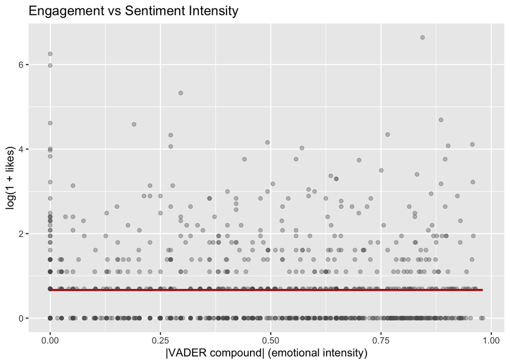

```r
posts |>
  mutate(
    sentiment_intensity = abs(vader_score),
    likes_log = log1p(like_count)
  ) |>
  ggplot(aes(x = sentiment_intensity, y = likes_log)) +
  geom_point(alpha = 0.35, color = "gray35") +
  geom_smooth(method = "lm", se = FALSE, color = "firebrick") +
  labs(
    title = "Engagement vs Sentiment Intensity",
    x = "|VADER compound| (emotional intensity)",
    y = "log(1 + likes)"
  )
```

**Bonus:** Is there a relationship between sentiment intensity and engagement? What does that suggest about what gets amplified on Bluesky?

There does not seem to be a relationship between sentiment intensity and engagement. The points are very scattered and the line is almost flat. This suggests that emotional intensity does not necessarily drive engagement on Bluesky, and other factors like author or timing might be more important in determining what gets amplified. Also a lot of posts that are very emotional have zero likes.